# Figure 2: `WT` maximum amplitudes and decay rate constants

## The Dataset

We process the `NeRh50_Table_S1_raw_data_used_in_figures.csv` dataset to obtain the data for this analysis (Table 1).

```r
# Show interactive tables of data
DT::datatable(dfms$dfm_fig2_amp)
DT::datatable(dfms$dfm_fig2_k)
# Write datasets to file (commented out for website)
#readr::write_csv(dfms$dfm_fig2_amp, "assets/data/01_fig2_amplitude.csv")
#readr::write_csv(dfms$dfm_fig2_k, "assets/data/01_fig2_rate.csv")
```

Table 1: Measurements for `WT` across `H2O`, `D2O` and `D2O>H2O` conditions at varying levels of `LPR`

(a) Maximum amplitude

|  | Variant | Condition | LPR | Value |
| --- | --- | --- | --- | --- |
| 1 | WT | H2O | LPR5 | 2.176 |
| 2 | WT | H2O | LPR5 | 2.228 |
| 3 | WT | H2O | LPR5 | 1.561 |
| 4 | WT | H2O | LPR5 | 1.986 |
| 5 | WT | H2O | LPR5 | 1.426 |
| 6 | WT | H2O | LPR5 | 1.606 |
| 7 | WT | H2O | LPR10 | 0.841 |
| 8 | WT | H2O | LPR10 | 1.005 |
| 9 | WT | H2O | LPR10 | 1.191 |
| 10 | WT | H2O | LPR10 | 1.275 |

[output cut: 26 more lines]

(b) Decay rate

|  | Variant | Condition | LPR | Value |
| --- | --- | --- | --- | --- |
| 1 | WT | H2O | LPR10 | 26.23 |
| 2 | WT | H2O | LPR10 | 50.98 |
| 3 | WT | H2O | LPR10 | 25.06 |
| 4 | WT | H2O | LPR10 | 21.63 |
| 5 | WT | H2O | LPR10 | 56.7 |
| 6 | WT | H2O | LPR50 | 10.765 |
| 7 | WT | H2O | LPR50 | 20.065 |
| 8 | WT | H2O | LPR50 | 18.58 |
| 9 | WT | H2O | LPR50 | 13.02 |
| 10 | WT | H2O | LPR5 | 49.27 |

[output cut: 26 more lines]

We visualise the datasets in the style of manuscript figure 2 in Figure 1.

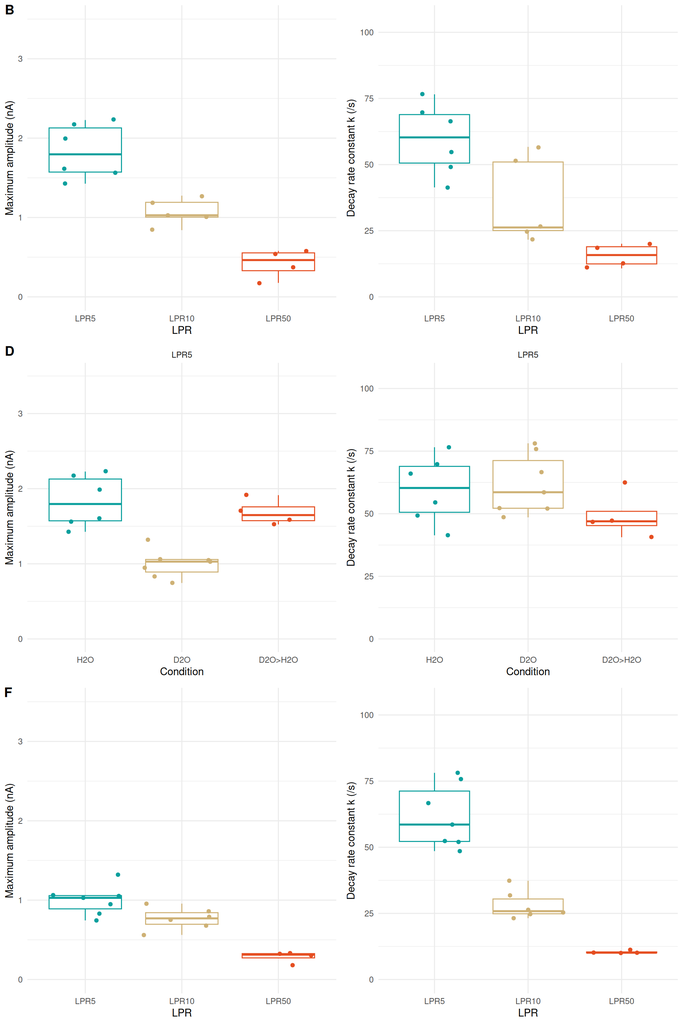

Figure 1: WT measurements across three `LPR`s and three experimental conditions, representing figures 2B, 2D, and 2F from the draft manuscript.

```r
p1b_amp <- ggplot2::ggplot(dfms$dfm_fig2_amp |> dplyr::filter(Condition == "H2O"),
                           ggplot2::aes(x=LPR, y=Value, color=LPR)) +
  ggplot2::geom_boxplot(outlier.shape = NA) +
  ggplot2::geom_jitter() +
  ggplot2::labs(y="Maximum amplitude (nA)") +
  ggplot2::ylim(0, 3.5) +
  ggplot2::theme_minimal()

p1b_k <- ggplot2::ggplot(dfms$dfm_fig2_k |> dplyr::filter(Condition == "H2O"),
                         ggplot2::aes(x=LPR, y=Value, color=LPR)) +
  ggplot2::geom_boxplot(outlier.shape = NA) +
  ggplot2::geom_jitter() +
  ggplot2::labs(y="Decay rate constant k (/s)") +
  ggplot2::ylim(0, 105) +
  ggplot2::theme_minimal()

p1d_amp <- ggplot2::ggplot(dfms$dfm_fig2_amp |> dplyr::filter(LPR == "LPR5"),
                           ggplot2::aes(x=Condition, y=Value, color=Condition)) +
  ggplot2::geom_boxplot(outlier.shape = NA) +
  ggplot2::geom_jitter() +
  ggplot2::labs(y="Maximum amplitude (nA)") +
  ggplot2::ylim(0, 3.5) +
  ggplot2::theme_minimal() +
  ggplot2::facet_wrap(~LPR)

p1d_k <- ggplot2::ggplot(dfms$dfm_fig2_k |> dplyr::filter(LPR == "LPR5"),
                         ggplot2::aes(x=Condition, y=Value, color=Condition)) +
  ggplot2::geom_boxplot(outlier.shape = NA) +
  ggplot2::geom_jitter() +
  ggplot2::labs(y="Decay rate constant k (/s)") +
  ggplot2::ylim(0, 105) +
  ggplot2::theme_minimal() +
  ggplot2::facet_wrap(~LPR)

p1f_amp <- ggplot2::ggplot(dfms$dfm_fig2_amp |> dplyr::filter(Condition == "D2O"),
                           ggplot2::aes(x=LPR, y=Value, color=LPR)) +
  ggplot2::geom_boxplot(outlier.shape = NA) +
  ggplot2::geom_jitter() +
  ggplot2::labs(y="Maximum amplitude (nA)") +
  ggplot2::ylim(0, 3.5) +
  ggplot2::theme_minimal()

p1f_k <- ggplot2::ggplot(dfms$dfm_fig2_k |> dplyr::filter(Condition == "D2O"),
                         ggplot2::aes(x=LPR, y=Value, color=LPR)) +
  ggplot2::geom_boxplot(outlier.shape = NA) +
  ggplot2::geom_jitter() +
  ggplot2::labs(y="Decay rate constant k (/s)") +
  ggplot2::ylim(0, 105) +
  ggplot2::theme_minimal()

ggpubr::ggarrange(p1b_amp, p1b_k, p1d_amp, p1d_k, p1f_amp, p1f_k,
                  ncol=2, nrow=3,
                  labels=c("B", "", "D", "", "F", ""),
                  legend="none")
```

### Downloads

- Download `01_fig2_amplitude.csv`
- Download `01_fig2_rate.csv`

## The Questions

We have multiple questions for this dataset. Within each of the six plots we wish to present the effects of the parameters plotted along the *x*-axis, for each measurement.

## The Models

We address these questions using a separate linear model for each set of figure data. For figures 2B and 2F we treat maximum amplitude and decay rate constant as dependent variables, and fit these to the `LPR` explanatory variable (`Value ~ LPR`). For figure 2D we proceed in a similar way, but fit to the `Condition` explanatory variable (`Value ~ Condition`).

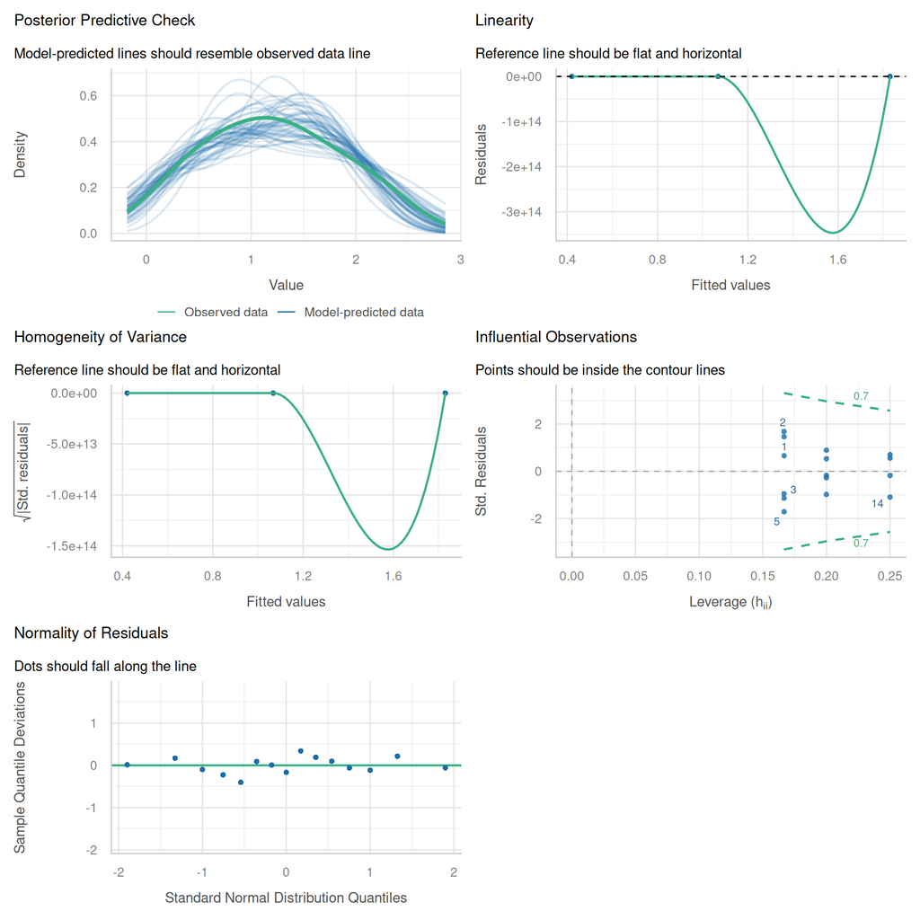

(a) Figure 2B(i)

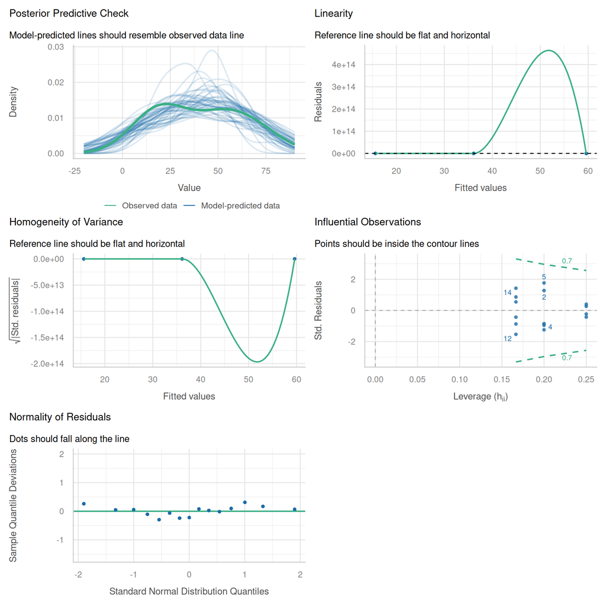

(b) Figure 2B(ii)

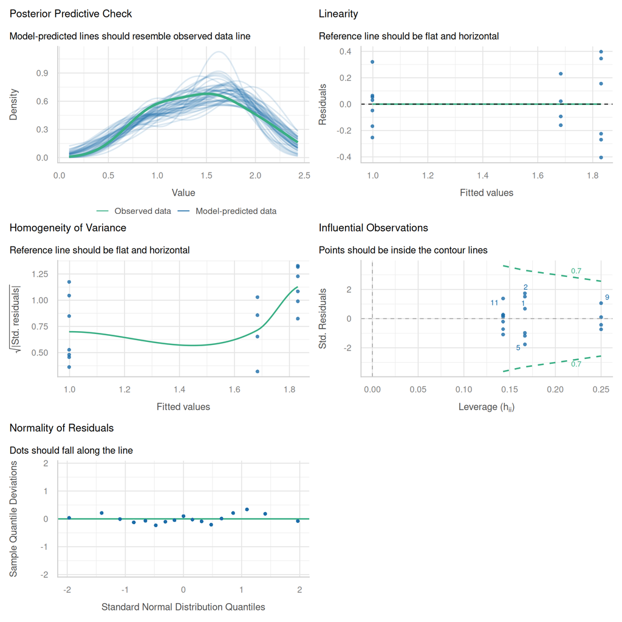

(c) Figure 2D(i)

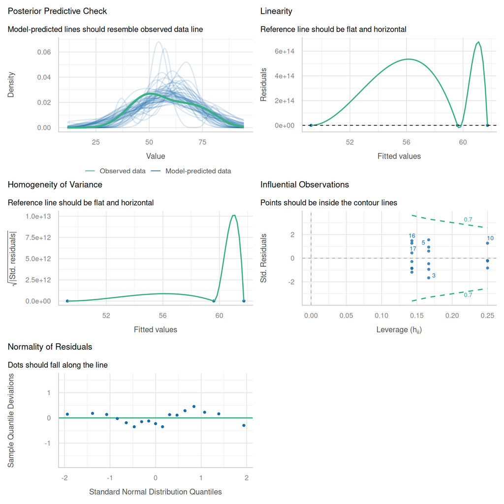

(d) Figure 2D(ii)

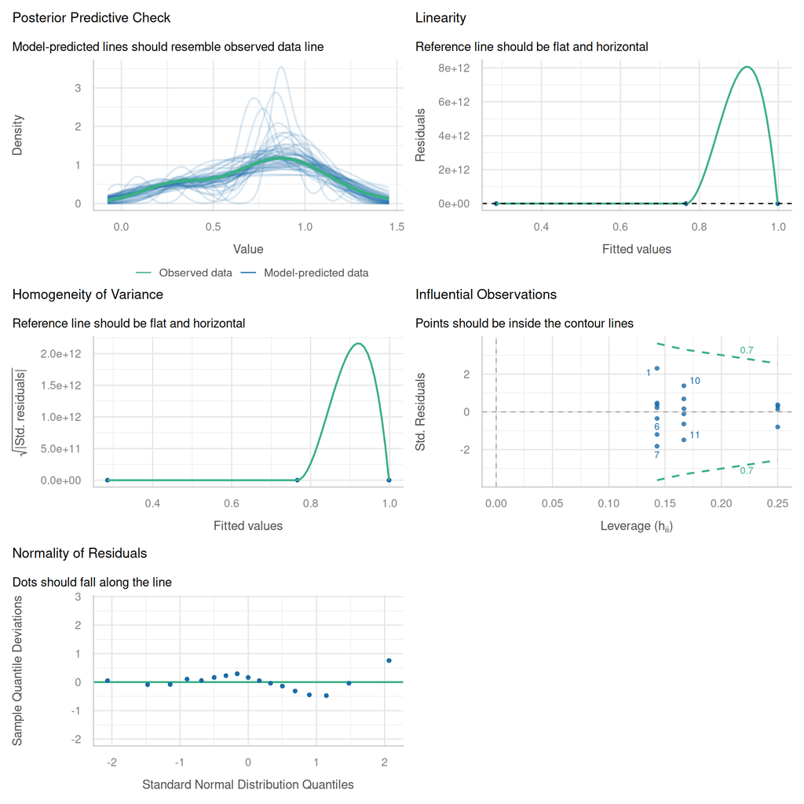

(e) Figure 2F(i)

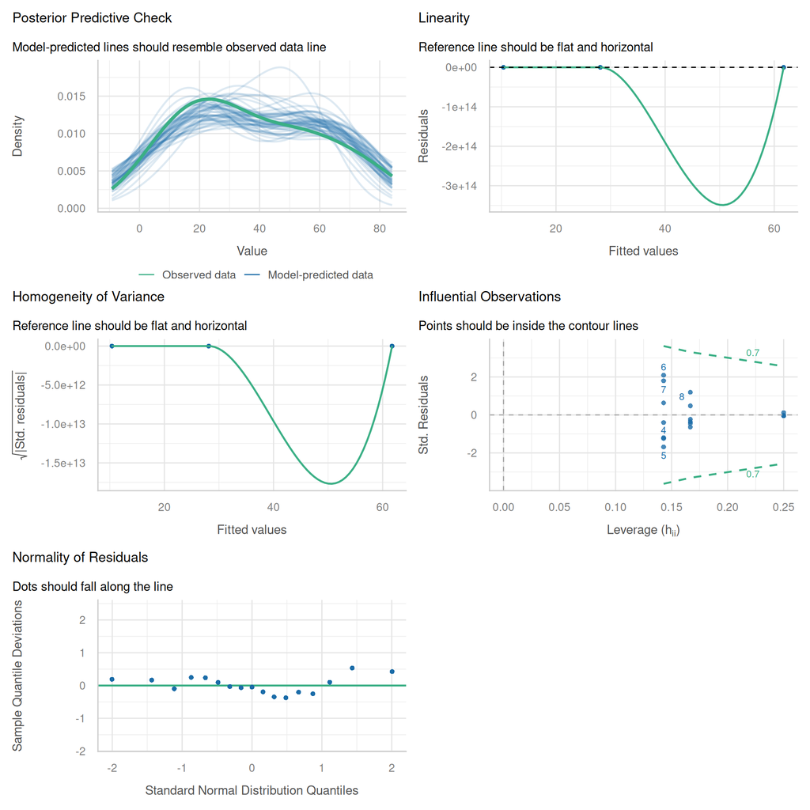

(f) Figure 2F(ii)

Figure 2: Diagnostic plots for linear model fits of `Value ~ LPR` and `Max_amplitude ~ Condition`

```r
model1b_amp_lm <- lm(Value ~ LPR, data=dfms$dfm_fig2_amp |> dplyr::filter(Condition == "H2O"))
model1b_k_lm <- lm(Value ~ LPR, data=dfms$dfm_fig2_k |> dplyr::filter(Condition == "H2O"))

model1d_lpr5_amp_lm <- lm(Value ~ Condition, data=dfms$dfm_fig2_amp |> dplyr::filter(LPR == "LPR5"))
model1d_lpr5_k_lm <- lm(Value ~ Condition, data=dfms$dfm_fig2_k |> dplyr::filter(LPR == "LPR5"))

model1f_amp_lm <- lm(Value ~ LPR, data=dfms$dfm_fig2_amp |> dplyr::filter(Condition == "D2O"))
model1f_k_lm <- lm(Value ~ LPR, data=dfms$dfm_fig2_k |> dplyr::filter(Condition == "D2O"))

performance::check_model(model1b_amp_lm, size_title=6)
performance::check_model(model1b_k_lm, size_title=6)
performance::check_model(model1d_lpr5_amp_lm, size_title=6)
performance::check_model(model1d_lpr5_k_lm, size_title=6)
performance::check_model(model1f_amp_lm, size_title=6)
performance::check_model(model1f_k_lm, size_title=6)
```

There are no obvious departures from assumptions in Figure 2, although some of the diagnostic plots do have odd spline fits. We extract the contrasts in Table 2.

```r
EMM <- emmeans::emmeans(model1b_amp_lm, ~ LPR)
confint(emmeans::contrast(EMM, "pairwise", adjust="sidak")) |>
  kableExtra::kbl(digits=3) |>
  kableExtra::kable_styling(
    bootstrap_options = c("hover", "responsive")
  )
EMM <- emmeans::emmeans(model1b_k_lm, ~ LPR)
confint(emmeans::contrast(EMM, "pairwise", adjust="sidak")) |>
  kableExtra::kbl(digits=3) |>
  kableExtra::kable_styling(
    bootstrap_options = c("hover", "responsive")
  )
EMM <- emmeans::emmeans(model1d_lpr5_amp_lm, ~ Condition)
confint(emmeans::contrast(EMM, "pairwise", adjust="sidak")) |>
  kableExtra::kbl(digits=3) |>
  kableExtra::kable_styling(
    bootstrap_options = c("hover", "responsive")
  )
EMM <- emmeans::emmeans(model1d_lpr5_k_lm, ~ Condition)
confint(emmeans::contrast(EMM, "pairwise", adjust="sidak")) |>
  kableExtra::kbl(digits=3) |>
  kableExtra::kable_styling(
    bootstrap_options = c("hover", "responsive")
  )
EMM <- emmeans::emmeans(model1f_amp_lm, ~ LPR)
confint(emmeans::contrast(EMM, "pairwise", adjust="sidak")) |>
  kableExtra::kbl(digits=3) |>
  kableExtra::kable_styling(
    bootstrap_options = c("hover", "responsive")
  )
EMM <- emmeans::emmeans(model1f_k_lm, ~ LPR)
confint(emmeans::contrast(EMM, "pairwise", adjust="sidak")) |>
  kableExtra::kbl(digits=3) |>
  kableExtra::kable_styling(
    bootstrap_options = c("hover", "responsive")
  )
```

Table 2: Contrasts for model fits, with Sidak adjustment.

(a) Figure 2B(i): Maximum amplitude, H2O

| contrast | estimate | SE | df | lower.CL | upper.CL |
| --- | --- | --- | --- | --- | --- |
| LPR5 - LPR10 | 0.762 | 0.157 | 12 | 0.328 | 1.197 |
| LPR5 - LPR50 | 1.410 | 0.167 | 12 | 0.947 | 1.873 |
| LPR10 - LPR50 | 0.648 | 0.174 | 12 | 0.166 | 1.129 |

(b) Figure 2B(ii): Decay rate, H2O

| contrast | estimate | SE | df | lower.CL | upper.CL |
| --- | --- | --- | --- | --- | --- |
| LPR5 - LPR10 | 23.482 | 7.882 | 12 | 1.646 | 45.317 |
| LPR5 - LPR50 | 43.994 | 8.402 | 12 | 20.718 | 67.271 |
| LPR10 - LPR50 | 20.512 | 8.732 | 12 | -3.677 | 44.702 |

(c) Figure 2D(i): Maximum amplitude, LPR5

| contrast | estimate | SE | df | lower.CL | upper.CL |
| --- | --- | --- | --- | --- | --- |
| H2O - D2O | 0.832 | 0.140 | 14 | 0.454 | 1.210 |
| H2O - D2O>H2O | 0.147 | 0.162 | 14 | -0.292 | 0.585 |
| D2O - D2O>H2O | -0.685 | 0.157 | 14 | -1.111 | -0.259 |

(d) Figure 2D(ii): Decay rate, LPR5

| contrast | estimate | SE | df | lower.CL | upper.CL |
| --- | --- | --- | --- | --- | --- |
| H2O - D2O | -2.128 | 6.675 | 14 | -20.210 | 15.954 |
| H2O - D2O>H2O | 10.351 | 7.744 | 14 | -10.628 | 31.331 |
| D2O - D2O>H2O | 12.479 | 7.520 | 14 | -7.892 | 32.851 |

(e) Figure 2F(i): Maximum amplitude, D2O

| contrast | estimate | SE | df | lower.CL | upper.CL |
| --- | --- | --- | --- | --- | --- |
| LPR5 - LPR10 | 0.232 | 0.084 | 14 | 0.006 | 0.458 |
| LPR5 - LPR50 | 0.713 | 0.094 | 14 | 0.458 | 0.968 |
| LPR10 - LPR50 | 0.481 | 0.097 | 14 | 0.218 | 0.743 |

(f) Figure 2F(ii): Decay rate, D2O

| contrast | estimate | SE | df | lower.CL | upper.CL |
| --- | --- | --- | --- | --- | --- |
| LPR5 - LPR10 | 33.607 | 4.709 | 14 | 20.849 | 46.366 |
| LPR5 - LPR50 | 51.345 | 5.306 | 14 | 36.972 | 65.718 |
| LPR10 - LPR50 | 17.738 | 5.464 | 14 | 2.935 | 32.540 |

The following contrasts are indicated not to include zero in their 95% confidence interval (estimates in Table 2), which we interpret as indicating an effect due to differing lipid-protein ratio, or differing solvent condition:

- `WT` Maximum amplitude, `H2O`: `LPR5-LPR10` (0.762nA [0.328,1.20]), `LPR10-LPR50` (0.648nA [0.166, 1.13]), `LPR5-LPR50` (1.41nA [0.947,1.87])
- `WT` Decay rate, `H2O`: `LPR5-LPR10` (23.5.s [1.65,45.3]), `LPR5-LPR50` (44.0/s [20.7,67.3])
- `WT` Maximum amplitude, `LPR5`: `H2O-D2O` (0.832nA [0.454,1.21]), `D2O-D2O>H2O` (-0.685nA [-1.11,-0.259])
- `WT` Decay rate, `LPR5`: no contrasts show significant difference
- `WT` Maximum amplitude, `D2O`: `LPR5-LPR10` (0.232nA [0.006,0.458]), `LPR10-LPR50` (0.481nA [0.218,0.743]), `LPR5-LPR50` (0.713nA [0.458,0.968])
- `WT` Decay rate, `D2O`: `LPR5-LPR10` (33.6/s [20.8,46.4]), `LPR5-LPR50` (51.3/s [37.0,65.7]), `LPR10-LPR50` (17.7/s [2.94,32.5])

## Figure

We can plot these differences in the style of the manuscript as in Figure 3

```r
# Get p-values, accounting for heteroscedasticity and multiple testing
# Also generate group1 and group2 columns
EMM_amp_b <- as.data.frame(pairs(emmeans::emmeans(model1b_amp_lm, ~ LPR),
                               adjust="sidak")) |>
  tidyr::separate(contrast, into=c("group1", "group2"), sep=" - ") |>
  dplyr::mutate(y.position=2.5) |>
  rstatix::add_significance()

EMM_k_b <- as.data.frame(pairs(emmeans::emmeans(model1b_k_lm, ~ LPR),
                               adjust="sidak")) |>
  tidyr::separate(contrast, into=c("group1", "group2"), sep=" - ") |>
  dplyr::mutate(y.position=85) |>
  rstatix::add_significance()

EMM_lpr5_amp_d <- as.data.frame(pairs(emmeans::emmeans(model1d_lpr5_amp_lm, ~ Condition),
                               adjust="sidak")) |>
  tidyr::separate(contrast, into=c("group1", "group2"), sep=" - ") |>
  dplyr::mutate(y.position=2.5) |>
  rstatix::add_significance() |>
  dplyr::mutate(LPR="LPR5")

EMM_lpr5_k_d <- as.data.frame(pairs(emmeans::emmeans(model1d_lpr5_k_lm, ~ Condition),
                               adjust="sidak")) |>
  tidyr::separate(contrast, into=c("group1", "group2"), sep=" - ") |>
  dplyr::mutate(y.position=85) |>
  rstatix::add_significance() |>
  dplyr::mutate(LPR="LPR5")

EMM_amp_f <- as.data.frame(pairs(emmeans::emmeans(model1f_amp_lm, ~ LPR),
                               adjust="sidak")) |>
  tidyr::separate(contrast, into=c("group1", "group2"), sep=" - ") |>
  dplyr::mutate(y.position=2.5) |>
  rstatix::add_significance()

EMM_k_f <- as.data.frame(pairs(emmeans::emmeans(model1f_k_lm, ~ LPR),
                               adjust="sidak")) |>
  tidyr::separate(contrast, into=c("group1", "group2"), sep=" - ") |>
  dplyr::mutate(y.position=85) |>
  rstatix::add_significance()

p1b_amp_annot <- p1b_amp +
  ggpubr::stat_pvalue_manual(EMM_amp_b,
                             label="p = {scales::pvalue(p.value)}",
                             size=3, step.increase=0.1)

p1b_k_annot <- p1b_k +
  ggpubr::stat_pvalue_manual(EMM_k_b,
                             label="p = {scales::pvalue(p.value)}",
                             size=3, step.increase=0.1)

p1d_amp_annot <- p1d_amp +
  ggpubr::stat_pvalue_manual(EMM_lpr5_amp_d,
                             label="p = {scales::pvalue(p.value)}",
                             size=3, step.increase=0.1)

p1d_k_annot <- p1d_k +
  ggpubr::stat_pvalue_manual(EMM_lpr5_k_d,
                             label="p = {scales::pvalue(p.value)}",
                             size=3, step.increase=0.1)

p1f_amp_annot <- p1f_amp +
  ggpubr::stat_pvalue_manual(EMM_amp_f,
                             label="p = {scales::pvalue(p.value)}",
                             size=3, step.increase=0.1)

p1f_k_annot <- p1f_k +
  ggpubr::stat_pvalue_manual(EMM_k_f,
                             label="p = {scales::pvalue(p.value)}",
                             size=3, step.increase=0.1)

p_comp <- ggpubr::ggarrange(p1b_amp_annot, p1b_k_annot, p1d_amp_annot,
                            p1d_k_annot, p1f_amp_annot, p1f_k_annot,
                            ncol=2, nrow=3,
                            labels=c("B", "", "D", "", "F", ""),
                            legend="none")
p_comp

# Write figures to file (commented out for webpage)
#ggplot2::ggsave("assets/images/fig02_WT_across_three_conditions_and_LPRs.pdf", p_comp)
#ggplot2::ggsave("assets/images/fig02_WT_across_three_conditions_and_LPRs.png", p_comp)
```

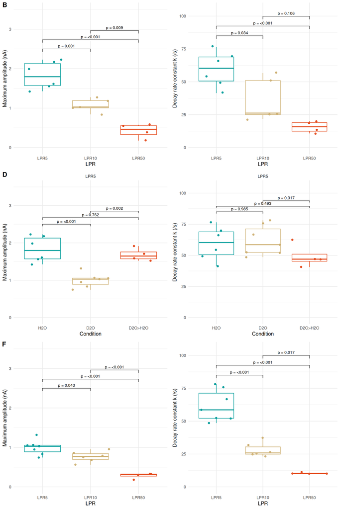

(a) Figure 2B(i)

Figure 3: WT measurements across three LPRs and three experimental conditions, representing figures 2B, 2D, and 2F from the draft manuscript. , with Sidak-adjusted *p*-values indicated

### Downloads

- Download as .pdf
- Download as .png